# Python 人工智能入门 毕业项目

# 机器学习预测金融风险

## 2019年3月29日

## 目录

- 定义
- 分析
- 实现
- 结果
- 结论

## Ⅰ.定义

### 1.项目概况

在信贷平台中，坏账率是一个很重要的指标。关系着公司的直接利益。在传统的方式中，我们一般通过申请人的信用信息，收入情况来评判申请人是否有偿还能力，是否会导致坏账。在本项目中，我们将通过机器学习算法对每一个申请人的基本信息、交易信息等数据进行甄别，多维度预测申请人坏账率。减少信贷公司的坏账损失。

现在集团收集了一段时间内玩家的贷款记录`loan.csv`。数据集包括了贷款人的基本信息，以及还款和未还款的信息。

### 2.问题陈述

在信贷平台中，坏账率是一个很重要的指标。关系着公司的直接利益。在传统的方式中，我们一般通过申请人的信用信息，收入情况来评判申请人是否有偿还能力，是否会导致坏账。在本项目中，我们将通过机器学习算法对每一个申请人的基本信息、交易信息等数据进行甄别，多维度预测申请人坏账率。减少信贷公司的坏账损失。

现在集团收集了一段时间内玩家的贷款记录`loan.csv` 以及字段描述集`LCDataDictionary.xlsx`。数据集包括了贷款人的基本信息，以及还款和未还款的信息。 通过分析数据集，能预测一个新的申请用户的坏账率的可能性。对于申请人来说，只有坏账和不坏帐两种情况。根据算法，我们可以推断这是一个分类问题。 将数据集分成20%测试集，80%验证集。在此案例中，我们不希望真实坏账的用户，被预测为不坏账的用户。那么，需要高精确度的结果。假定我们希望的精确度是90%。

## Ⅱ.分析

```python
import numpy as np
import pandas as pd
import matplotlib.pyplot as plt
%matplotlib inline
```

```python
# 请在这一代码框内编写在这部分你需要的程序
# 包括但不限于
# * 导入数据
df = pd.read_csv('loan.csv')

# * 绘制可以表达你想法的图像
# 你可以自由的使用任意数量和任意格式的代码框，但请在最终提交的报告中注意报告的整洁与通顺
# 查看数据的前5行
df.head()
```

|  | id | member_id | loan_amnt | funded_amnt | funded_amnt_inv | term | int_rate | installment | grade | sub_grade | ... | total_bal_il | il_util | open_rv_12m | open_rv_24m | max_bal_bc | all_util | total_rev_hi_lim | inq_fi | total_cu_tl | inq_last_12m |
| --- | --- | --- | --- | --- | --- | --- | --- | --- | --- | --- | --- | --- | --- | --- | --- | --- | --- | --- | --- | --- | --- |
| 0 | 1077501 | 1296599 | 5000.0 | 5000.0 | 4975.0 | 36 months | 10.65 | 162.87 | B | B2 | ... | NaN | NaN | NaN | NaN | NaN | NaN | NaN | NaN | NaN | NaN |
| 1 | 1077430 | 1314167 | 2500.0 | 2500.0 | 2500.0 | 60 months | 15.27 | 59.83 | C | C4 | ... | NaN | NaN | NaN | NaN | NaN | NaN | NaN | NaN | NaN | NaN |
| 2 | 1077175 | 1313524 | 2400.0 | 2400.0 | 2400.0 | 36 months | 15.96 | 84.33 | C | C5 | ... | NaN | NaN | NaN | NaN | NaN | NaN | NaN | NaN | NaN | NaN |
| 3 | 1076863 | 1277178 | 10000.0 | 10000.0 | 10000.0 | 36 months | 13.49 | 339.31 | C | C1 | ... | NaN | NaN | NaN | NaN | NaN | NaN | NaN | NaN | NaN | NaN |
| 4 | 1075358 | 1311748 | 3000.0 | 3000.0 | 3000.0 | 60 months | 12.69 | 67.79 | B | B5 | ... | NaN | NaN | NaN | NaN | NaN | NaN | NaN | NaN | NaN | NaN |

5 rows × 74 columns

```python
# 查看数据的基本信息
df.info()
```

```
<class 'pandas.core.frame.DataFrame'>
RangeIndex: 887379 entries, 0 to 887378
Data columns (total 74 columns):
id                             887379 non-null int64
member_id                      887379 non-null int64
loan_amnt                      887379 non-null float64
funded_amnt                    887379 non-null float64
funded_amnt_inv                887379 non-null float64
term                           887379 non-null object
int_rate                       887379 non-null float64
installment                    887379 non-null float64
grade                          887379 non-null object
sub_grade                      887379 non-null object
emp_title                      835917 non-null object
emp_length                     842554 non-null object
home_ownership                 887379 non-null object
annual_inc                     887375 non-null float64
verification_status            887379 non-null object
issue_d                        887379 non-null object
loan_status                    887379 non-null object
pymnt_plan                     887379 non-null object
url                            887379 non-null object
desc                           126028 non-null object
purpose                        887379 non-null object
title                          887227 non-null object
zip_code                       887379 non-null object
addr_state                     887379 non-null object
dti                            887379 non-null float64
delinq_2yrs                    887350 non-null float64
earliest_cr_line               887350 non-null object
inq_last_6mths                 887350 non-null float64
mths_since_last_delinq         433067 non-null float64
mths_since_last_record         137053 non-null float64
open_acc                       887350 non-null float64
pub_rec                        887350 non-null float64
revol_bal                      887379 non-null float64
revol_util                     886877 non-null float64
total_acc                      887350 non-null float64
initial_list_status            887379 non-null object
out_prncp                      887379 non-null float64
```

[output cut: 24 more lines]

```
open_il_12m                    21372 non-null float64
open_il_24m                    21372 non-null float64
mths_since_rcnt_il             20810 non-null float64
total_bal_il                   21372 non-null float64
il_util                        18617 non-null float64
open_rv_12m                    21372 non-null float64
open_rv_24m                    21372 non-null float64
max_bal_bc                     21372 non-null float64
all_util                       21372 non-null float64
total_rev_hi_lim               817103 non-null float64
inq_fi                         21372 non-null float64
total_cu_tl                    21372 non-null float64
inq_last_12m                   21372 non-null float64
dtypes: float64(49), int64(2), object(23)
memory usage: 501.0+ MB
```

#### 我们查看了数据集的基本信息，总数据行数为 887379。

```python
# 查看数据的基本描述
df.describe()
```

|  | id | member_id | loan_amnt | funded_amnt | funded_amnt_inv | int_rate | installment | annual_inc | dti | delinq_2yrs | ... | total_bal_il | il_util | open_rv_12m | open_rv_24m | max_bal_bc | all_util | total_rev_hi_lim | inq_fi | total_cu_tl | inq_last_12m |
| --- | --- | --- | --- | --- | --- | --- | --- | --- | --- | --- | --- | --- | --- | --- | --- | --- | --- | --- | --- | --- | --- |
| count | 8.873790e+05 | 8.873790e+05 | 887379.000000 | 887379.000000 | 887379.000000 | 887379.000000 | 887379.000000 | 8.873750e+05 | 887379.000000 | 887350.000000 | ... | 21372.000000 | 18617.000000 | 21372.000000 | 21372.000000 | 21372.000000 | 21372.000000 | 8.171030e+05 | 21372.000000 | 21372.000000 | 21372.000000 |
| mean | 3.246513e+07 | 3.500182e+07 | 14755.264605 | 14741.877625 | 14702.464383 | 13.246740 | 436.717127 | 7.502759e+04 | 18.157039 | 0.314442 | ... | 36552.811389 | 71.535317 | 1.389060 | 2.975482 | 5887.979740 | 60.831939 | 3.206862e+04 | 0.943945 | 1.537058 | 1.977307 |
| std | 2.282734e+07 | 2.411335e+07 | 8435.455601 | 8429.897657 | 8442.106732 | 4.381867 | 244.186593 | 6.469830e+04 | 17.190626 | 0.862244 | ... | 43103.833619 | 23.022862 | 1.520129 | 2.631886 | 5284.701239 | 20.013254 | 3.749826e+04 | 1.446872 | 2.723339 | 2.874067 |
| min | 5.473400e+04 | 7.047300e+04 | 500.000000 | 500.000000 | 0.000000 | 5.320000 | 15.670000 | 0.000000e+00 | 0.000000 | 0.000000 | ... | 0.000000 | 0.000000 | 0.000000 | 0.000000 | 0.000000 | 0.000000 | 0.000000e+00 | 0.000000 | 0.000000 | -4.000000 |
| 25% | 9.206643e+06 | 1.087713e+07 | 8000.000000 | 8000.000000 | 8000.000000 | 9.990000 | 260.705000 | 4.500000e+04 | 11.910000 | 0.000000 | ... | 10251.500000 | 58.600000 | 0.000000 | 1.000000 | 2411.000000 | 47.700000 | 1.390000e+04 | 0.000000 | 0.000000 | 0.000000 |
| 50% | 3.443327e+07 | 3.709528e+07 | 13000.000000 | 13000.000000 | 13000.000000 | 12.990000 | 382.550000 | 6.500000e+04 | 17.650000 | 0.000000 | ... | 24684.500000 | 74.900000 | 1.000000 | 2.000000 | 4483.000000 | 61.900000 | 2.370000e+04 | 0.000000 | 0.000000 | 2.000000 |
| 75% | 5.490814e+07 | 5.847135e+07 | 20000.000000 | 20000.000000 | 20000.000000 | 16.200000 | 572.600000 | 9.000000e+04 | 23.950000 | 0.000000 | ... | 47858.000000 | 87.600000 | 2.000000 | 4.000000 | 7771.500000 | 75.200000 | 3.980000e+04 | 1.000000 | 2.000000 | 3.000000 |
| max | 6.861706e+07 | 7.354484e+07 | 35000.000000 | 35000.000000 | 35000.000000 | 28.990000 | 1445.460000 | 9.500000e+06 | 9999.000000 | 39.000000 | ... | 878459.000000 | 223.300000 | 22.000000 | 43.000000 | 127305.000000 | 151.400000 | 9.999999e+06 | 17.000000 | 35.000000 | 32.000000 |

8 rows × 51 columns

### 分析

```python
#查看结果集数据的种类的数量
df.loan_status.value_counts()
```

```
Current                                                601779
Fully Paid                                             207723
Charged Off                                             45248
Late (31-120 days)                                      11591
Issued                                                   8460
In Grace Period                                          6253
Late (16-30 days)                                        2357
Does not meet the credit policy. Status:Fully Paid       1988
Default                                                  1219
Does not meet the credit policy. Status:Charged Off       761
Name: loan_status, dtype: int64
```

```python
#通过结果集 我们对一些结果进行合并处理
#合并一些数据
df[df.loan_status == 'Does not meet the credit policy. Status:Fully Paid'] = 'Fully Paid'
df[df.loan_status == 'Does not meet the credit policy. Status:Charged Off'] = 'Charged Off'

df.loan_status.value_counts()
```

```
Current               601779
Fully Paid            209711
Charged Off            46009
Late (31-120 days)     11591
Issued                  8460
In Grace Period         6253
Late (16-30 days)       2357
Default                 1219
Name: loan_status, dtype: int64
```

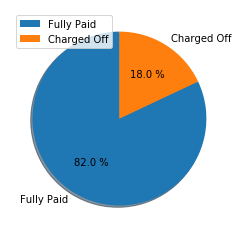

```python
#绘制结果数据
loan_df = df[(df.loan_status == 'Fully Paid') | (df.loan_status  == 'Charged Off')].loan_status.value_counts()
labels = ['Fully Paid', 'Charged Off']
plt.pie(loan_df,labels=labels, autopct='%3.1f %%',
        shadow=True, labeldistance=1.1, startangle = 90,pctdistance = 0.6)
plt.legend()
```

#### 说明

这里我们希望研究的是坏账率。在`loan_status`中，存在多个状态:

- Current：当前正常的贷款(这里不确定是否会最终坏账，所以剔除)。
- Fully Paid：完全偿还的贷款。
- Charged Off：坏账。
- Late(31-120 days): 滞纳31-120天的贷款。
- Issued: 有疑问的贷款。
- In Grace Perid: 在宽限期。
- Late(16-30 days): 滞纳16-30天的贷款。
- Default: 某种默认状态。 所以，只有已经确定为还款和确定为坏账的数据才能作为参考数据。 当前为`Fully Paid` 和 `Charged Off`状态可作为参考数据 我们注意到有一个状态`Default`意义不明确，做如下研究

```python
#当前Default 的比例
df[df.loan_status == 'Default'].shape[0]/df[(df.loan_status == 'Fully Paid') | (df.loan_status  == 'Charged Off')].shape[0]
```

```
0.0047669325825121225
```

当前`Default`状态的数据样本太少且意义不明，所以不采用

```python
(df['loan_amnt'] != df['funded_amnt']).mean()
```

```
0.0021648021871150886
```

通过对结果集的分析，我们可以知道。当前有18%的坏账率。

```python
df.columns
```

```
Index(['id', 'member_id', 'loan_amnt', 'funded_amnt', 'funded_amnt_inv',
       'term', 'int_rate', 'installment', 'grade', 'sub_grade', 'emp_title',
       'emp_length', 'home_ownership', 'annual_inc', 'verification_status',
       'issue_d', 'loan_status', 'pymnt_plan', 'url', 'desc', 'purpose',
       'title', 'zip_code', 'addr_state', 'dti', 'delinq_2yrs',
       'earliest_cr_line', 'inq_last_6mths', 'mths_since_last_delinq',
       'mths_since_last_record', 'open_acc', 'pub_rec', 'revol_bal',
       'revol_util', 'total_acc', 'initial_list_status', 'out_prncp',
       'out_prncp_inv', 'total_pymnt', 'total_pymnt_inv', 'total_rec_prncp',
       'total_rec_int', 'total_rec_late_fee', 'recoveries',
       'collection_recovery_fee', 'last_pymnt_d', 'last_pymnt_amnt',
       'next_pymnt_d', 'last_credit_pull_d', 'collections_12_mths_ex_med',
       'mths_since_last_major_derog', 'policy_code', 'application_type',
       'annual_inc_joint', 'dti_joint', 'verification_status_joint',
       'acc_now_delinq', 'tot_coll_amt', 'tot_cur_bal', 'open_acc_6m',
       'open_il_6m', 'open_il_12m', 'open_il_24m', 'mths_since_rcnt_il',
       'total_bal_il', 'il_util', 'open_rv_12m', 'open_rv_24m', 'max_bal_bc',
       'all_util', 'total_rev_hi_lim', 'inq_fi', 'total_cu_tl',
       'inq_last_12m'],
      dtype='object')
```

```python
# 读取数据字典 确定每个字段的意义
df_dic=pd.read_excel('LCDataDictionary.xlsx' , index_col='LoanStatNew')
pd.set_option('display.max_colwidth',500)
pd.set_option('display.max_rows',90)
df_dic.loc[df.columns]
```

| LoanStatNew | Description |
| --- | --- |
| id | A unique LC assigned ID for the loan listing. |
| member_id | A unique LC assigned Id for the borrower member. |
| loan_amnt | The listed amount of the loan applied for by the borrower. If at some point in time, the credit department reduces the loan amount, then it will be reflected in this value. |
| funded_amnt | The total amount committed to that loan at that point in time. |
| funded_amnt_inv | The total amount committed by investors for that loan at that point in time. |
| term | The number of payments on the loan. Values are in months and can be either 36 or 60. |
| int_rate | Interest Rate on the loan |
| installment | The monthly payment owed by the borrower if the loan originates. |
| grade | LC assigned loan grade |
| sub_grade | LC assigned loan subgrade |
| emp_title | The job title supplied by the Borrower when applying for the loan.* |
| emp_length | Employment length in years. Possible values are between 0 and 10 where 0 means less than one year and 10 means ten or more years. |
| home_ownership | The home ownership status provided by the borrower during registration. Our values are: RENT, OWN, MORTGAGE, OTHER. |
| annual_inc | The self-reported annual income provided by the borrower during registration. |
| verification_status | NaN |
| issue_d | The month which the loan was funded |
| loan_status | Current status of the loan |
| pymnt_plan | Indicates if a payment plan has been put in place for the loan |
| url | URL for the LC page with listing data. |
| desc | Loan description provided by the borrower |
| purpose | A category provided by the borrower for the loan request. |
| title | The loan title provided by the borrower |
| zip_code | The first 3 numbers of the zip code provided by the borrower in the loan application. |
| addr_state | The state provided by the borrower in the loan application |
| dti | A ratio calculated using the borrower’s total monthly debt payments on the total debt obligations, excluding mortgage and the requested LC loan, divided by the borrower’s self-reported monthly income. |
| delinq_2yrs | The number of 30+ days past-due incidences of delinquency in the borrower's credit file for the past 2 years |
| earliest_cr_line | The month the borrower's earliest reported credit line was opened |
| inq_last_6mths | The number of inquiries in past 6 months (excluding auto and mortgage inquiries) |
| mths_since_last_delinq | The number of months since the borrower's last delinquency. |
| mths_since_last_record | The number of months since the last public record. |
| open_acc | The number of open credit lines in the borrower's credit file. |
| pub_rec | Number of derogatory public records |
| revol_bal | Total credit revolving balance |
| revol_util | Revolving line utilization rate, or the amount of credit the borrower is using relative to all available revolving credit. |
| total_acc | The total number of credit lines currently in the borrower's credit file |
| initial_list_status | The initial listing status of the loan. Possible values are – W, F |
| out_prncp | Remaining outstanding principal for total amount funded |
| out_prncp_inv | Remaining outstanding principal for portion of total amount funded by investors |
| total_pymnt | Payments received to date for total amount funded |
| total_pymnt_inv | Payments received to date for portion of total amount funded by investors |
| total_rec_prncp | Principal received to date |
| total_rec_int | Interest received to date |
| total_rec_late_fee | Late fees received to date |
| recoveries | post charge off gross recovery |
| collection_recovery_fee | post charge off collection fee |
| last_pymnt_d | Last month payment was received |
| last_pymnt_amnt | Last total payment amount received |
| next_pymnt_d | Next scheduled payment date |
| last_credit_pull_d | The most recent month LC pulled credit for this loan |
| collections_12_mths_ex_med | Number of collections in 12 months excluding medical collections |
| mths_since_last_major_derog | Months since most recent 90-day or worse rating |
| policy_code | publicly available policy_code=1\nnew products not publicly available policy_code=2 |
| application_type | Indicates whether the loan is an individual application or a joint application with two co-borrowers |
| annual_inc_joint | The combined self-reported annual income provided by the co-borrowers during registration |
| dti_joint | A ratio calculated using the co-borrowers' total monthly payments on the total debt obligations, excluding mortgages and the requested LC loan, divided by the co-borrowers' combined self-reported mont… |
| verification_status_joint | NaN |
| acc_now_delinq | The number of accounts on which the borrower is now delinquent. |
| tot_coll_amt | Total collection amounts ever owed |
| tot_cur_bal | Total current balance of all accounts |
| open_acc_6m | Number of open trades in last 6 months |
| open_il_6m | Number of currently active installment trades |
| open_il_12m | Number of installment accounts opened in past 12 months |
| open_il_24m | Number of installment accounts opened in past 24 months |
| mths_since_rcnt_il | Months since most recent installment accounts opened |
| total_bal_il | Total current balance of all installment accounts |
| il_util | Ratio of total current balance to high credit/credit limit on all install acct |
| open_rv_12m | Number of revolving trades opened in past 12 months |
| open_rv_24m | Number of revolving trades opened in past 24 months |
| max_bal_bc | Maximum current balance owed on all revolving accounts |
| all_util | Balance to credit limit on all trades |
| total_rev_hi_lim | NaN |
| inq_fi | Number of personal finance inquiries |
| total_cu_tl | Number of finance trades |
| inq_last_12m | Number of credit inquiries in past 12 months |

#### 通过以上字段分析，人为先做第一步判断。分离出可能会影响结果的数据

- `annual_inc` 和 `annual_inc_joint` 均为申报收入 合并为`annual_inc`
- `dti` 和 `dti_joint` 均为负债率 合并为 `dti`
- `delinq_2yrs` 过去两年发生30天以上拖欠事件的次数
- `emp_length` 雇佣年数
- `home_ownership` 房屋居住情况
- `pub_rec` 贬损的公共记录数量
- `funded_amnt` 批复金额 float
- `term` 贷款期限 string
- `int_rate` 利率 float
- `grade` 贷款等级 分类数据 A B C D E F G 7个等级

## Ⅲ. 实现

```python
#因为本次是处理坏账率的数据 当前正常支付数据无法判断是否会坏账 所以 我们只留下Fully Paid 和 Charged Off的数据
df = df[(df.loan_status == 'Fully Paid') | (df.loan_status == 'Charged Off')]
```

```python
# 找到关键的字段

df_clean =  df[['loan_status', 'application_type', 'annual_inc', 'annual_inc_joint', 'dti', 'dti_joint','delinq_2yrs','emp_length','home_ownership','pub_rec','funded_amnt','term','int_rate','grade']]

df_clean.head()
```

|  | loan_status | application_type | annual_inc | annual_inc_joint | dti | dti_joint | delinq_2yrs | emp_length | home_ownership | pub_rec | funded_amnt | term | int_rate | grade |
| --- | --- | --- | --- | --- | --- | --- | --- | --- | --- | --- | --- | --- | --- | --- |
| 0 | Fully Paid | INDIVIDUAL | 24000 | NaN | 27.65 | NaN | 0 | 10+ years | RENT | 0 | 5000 | 36 months | 10.65 | B |
| 1 | Charged Off | INDIVIDUAL | 30000 | NaN | 1 | NaN | 0 | < 1 year | RENT | 0 | 2500 | 60 months | 15.27 | C |
| 2 | Fully Paid | INDIVIDUAL | 12252 | NaN | 8.72 | NaN | 0 | 10+ years | RENT | 0 | 2400 | 36 months | 15.96 | C |
| 3 | Fully Paid | INDIVIDUAL | 49200 | NaN | 20 | NaN | 0 | 10+ years | RENT | 0 | 10000 | 36 months | 13.49 | C |
| 5 | Fully Paid | INDIVIDUAL | 36000 | NaN | 11.2 | NaN | 0 | 3 years | RENT | 0 | 5000 | 36 months | 7.9 | A |

```python
# 合并 独立借贷人 和 联合借贷人的数据
df_clean[df_clean.application_type == 'JOINT'].loc[:,['annual_inc', 'dti']] = df_clean[df_clean.application_type == 'JOINT'].loc[:,['annual_inc_joint', 'dti_joint']]
# 删除联合借贷人的数据
df_clean.drop(['application_type','annual_inc_joint', 'dti_joint'], axis=1, inplace=True)
df_clean.head()
```

|  | loan_status | annual_inc | dti | delinq_2yrs | emp_length | home_ownership | pub_rec | funded_amnt | term | int_rate | grade |
| --- | --- | --- | --- | --- | --- | --- | --- | --- | --- | --- | --- |
| 0 | Fully Paid | 24000 | 27.65 | 0 | 10+ years | RENT | 0 | 5000 | 36 months | 10.65 | B |
| 1 | Charged Off | 30000 | 1 | 0 | < 1 year | RENT | 0 | 2500 | 60 months | 15.27 | C |
| 2 | Fully Paid | 12252 | 8.72 | 0 | 10+ years | RENT | 0 | 2400 | 36 months | 15.96 | C |
| 3 | Fully Paid | 49200 | 20 | 0 | 10+ years | RENT | 0 | 10000 | 36 months | 13.49 | C |
| 5 | Fully Paid | 36000 | 11.2 | 0 | 3 years | RENT | 0 | 5000 | 36 months | 7.9 | A |

```python
#处理emp_length的虚拟变量
#通过值统计 我们发现 Fully Paid 和 Charge Off 我们推测是误填
df_clean['emp_length'].value_counts()
```

```
10+ years      76881
2 years        23561
< 1 year       20886
3 years        20380
5 years        18059
1 year         16856
4 years        16197
6 years        14753
7 years        14085
8 years        11849
9 years         9567
Fully Paid      1988
Charged Off      761
Name: emp_length, dtype: int64
```

```python
#验证是误填的假设 得出结论是误填
df_clean[df_clean['emp_length'] == df_clean['loan_status']].shape[0]
```

```
2749
```

```python
# 删除误填的字段
df_clean = df_clean[(df_clean.emp_length != 'Fully Paid') & (df_clean.emp_length != 'Charged Off')]
# 验证是否删除
df_clean.emp_length.value_counts()
```

```
10+ years    76881
2 years      23561
< 1 year     20886
3 years      20380
5 years      18059
1 year       16856
4 years      16197
6 years      14753
7 years      14085
8 years      11849
9 years       9567
Name: emp_length, dtype: int64
```

```python
# 生成emp_length 的虚拟变量
df_clean = df_clean.join(pd.get_dummies(df_clean['emp_length']).iloc[:,1:])
df_clean.head()
```

|  | loan_status | annual_inc | dti | delinq_2yrs | emp_length | home_ownership | pub_rec | funded_amnt | term | int_rate | ... | 10+ years | 2 years | 3 years | 4 years | 5 years | 6 years | 7 years | 8 years | 9 years | < 1 year |
| --- | --- | --- | --- | --- | --- | --- | --- | --- | --- | --- | --- | --- | --- | --- | --- | --- | --- | --- | --- | --- | --- |
| 0 | Fully Paid | 24000 | 27.65 | 0 | 10+ years | RENT | 0 | 5000 | 36 months | 10.65 | ... | 1 | 0 | 0 | 0 | 0 | 0 | 0 | 0 | 0 | 0 |
| 1 | Charged Off | 30000 | 1 | 0 | < 1 year | RENT | 0 | 2500 | 60 months | 15.27 | ... | 0 | 0 | 0 | 0 | 0 | 0 | 0 | 0 | 0 | 1 |
| 2 | Fully Paid | 12252 | 8.72 | 0 | 10+ years | RENT | 0 | 2400 | 36 months | 15.96 | ... | 1 | 0 | 0 | 0 | 0 | 0 | 0 | 0 | 0 | 0 |
| 3 | Fully Paid | 49200 | 20 | 0 | 10+ years | RENT | 0 | 10000 | 36 months | 13.49 | ... | 1 | 0 | 0 | 0 | 0 | 0 | 0 | 0 | 0 | 0 |
| 5 | Fully Paid | 36000 | 11.2 | 0 | 3 years | RENT | 0 | 5000 | 36 months | 7.9 | ... | 0 | 0 | 1 | 0 | 0 | 0 | 0 | 0 | 0 | 0 |

5 rows × 21 columns

```python
#查看home_ownership中的分类
df_clean['home_ownership'].value_counts()
```

```
MORTGAGE    124844
RENT        105957
OWN          21985
OTHER          141
NONE            43
ANY              1
Name: home_ownership, dtype: int64
```

```python
#发现除了MORTAGE RENT 和 OWN 3种之外 其他数据数量较少 不具备分析价值 删除多余的种类
df_clean = df_clean[df_clean.home_ownership.isin(['MORTGAGE', 'RENT', 'OWN'])]
df_clean['home_ownership'].value_counts()
```

```
MORTGAGE    124844
RENT        105957
OWN          21985
Name: home_ownership, dtype: int64
```

```python
#生成home_ownership的虚拟变量
df_clean = df_clean.join(pd.get_dummies(df_clean['home_ownership']).iloc[:,1:])
df_clean.head()
```

|  | loan_status | annual_inc | dti | delinq_2yrs | emp_length | home_ownership | pub_rec | funded_amnt | term | int_rate | ... | 3 years | 4 years | 5 years | 6 years | 7 years | 8 years | 9 years | < 1 year | OWN | RENT |
| --- | --- | --- | --- | --- | --- | --- | --- | --- | --- | --- | --- | --- | --- | --- | --- | --- | --- | --- | --- | --- | --- |
| 0 | Fully Paid | 24000 | 27.65 | 0 | 10+ years | RENT | 0 | 5000 | 36 months | 10.65 | ... | 0 | 0 | 0 | 0 | 0 | 0 | 0 | 0 | 0 | 1 |
| 1 | Charged Off | 30000 | 1 | 0 | < 1 year | RENT | 0 | 2500 | 60 months | 15.27 | ... | 0 | 0 | 0 | 0 | 0 | 0 | 0 | 1 | 0 | 1 |
| 2 | Fully Paid | 12252 | 8.72 | 0 | 10+ years | RENT | 0 | 2400 | 36 months | 15.96 | ... | 0 | 0 | 0 | 0 | 0 | 0 | 0 | 0 | 0 | 1 |
| 3 | Fully Paid | 49200 | 20 | 0 | 10+ years | RENT | 0 | 10000 | 36 months | 13.49 | ... | 0 | 0 | 0 | 0 | 0 | 0 | 0 | 0 | 0 | 1 |
| 5 | Fully Paid | 36000 | 11.2 | 0 | 3 years | RENT | 0 | 5000 | 36 months | 7.9 | ... | 1 | 0 | 0 | 0 | 0 | 0 | 0 | 0 | 0 | 1 |

5 rows × 23 columns

```python
# 查看term中的分类
df_clean['term'].value_counts()  # 数据没有问题
```

```
 36 months    196482
 60 months     56304
Name: term, dtype: int64
```

```python
# 生成term的虚拟变量
df_clean = df_clean.join(pd.get_dummies(df_clean['term']).iloc[:,1:])
df_clean.head()
```

|  | loan_status | annual_inc | dti | delinq_2yrs | emp_length | home_ownership | pub_rec | funded_amnt | term | int_rate | ... | 4 years | 5 years | 6 years | 7 years | 8 years | 9 years | < 1 year | OWN | RENT | 60 months |
| --- | --- | --- | --- | --- | --- | --- | --- | --- | --- | --- | --- | --- | --- | --- | --- | --- | --- | --- | --- | --- | --- |
| 0 | Fully Paid | 24000 | 27.65 | 0 | 10+ years | RENT | 0 | 5000 | 36 months | 10.65 | ... | 0 | 0 | 0 | 0 | 0 | 0 | 0 | 0 | 1 | 0 |
| 1 | Charged Off | 30000 | 1 | 0 | < 1 year | RENT | 0 | 2500 | 60 months | 15.27 | ... | 0 | 0 | 0 | 0 | 0 | 0 | 1 | 0 | 1 | 1 |
| 2 | Fully Paid | 12252 | 8.72 | 0 | 10+ years | RENT | 0 | 2400 | 36 months | 15.96 | ... | 0 | 0 | 0 | 0 | 0 | 0 | 0 | 0 | 1 | 0 |
| 3 | Fully Paid | 49200 | 20 | 0 | 10+ years | RENT | 0 | 10000 | 36 months | 13.49 | ... | 0 | 0 | 0 | 0 | 0 | 0 | 0 | 0 | 1 | 0 |
| 5 | Fully Paid | 36000 | 11.2 | 0 | 3 years | RENT | 0 | 5000 | 36 months | 7.9 | ... | 0 | 0 | 0 | 0 | 0 | 0 | 0 | 0 | 1 | 0 |

5 rows × 24 columns

```python
#查看grade的分类 有A - G 的数据类型
df_clean['grade'].value_counts()
```

```
B    76003
C    65274
A    42265
D    40476
E    19178
F     7653
G     1937
Name: grade, dtype: int64
```

```python
# 生成grade的虚拟变量
df_clean = df_clean.join(pd.get_dummies(df_clean['grade']).iloc[:,1:])
df_clean.head()
```

|  | loan_status | annual_inc | dti | delinq_2yrs | emp_length | home_ownership | pub_rec | funded_amnt | term | int_rate | ... | < 1 year | OWN | RENT | 60 months | B | C | D | E | F | G |
| --- | --- | --- | --- | --- | --- | --- | --- | --- | --- | --- | --- | --- | --- | --- | --- | --- | --- | --- | --- | --- | --- |
| 0 | Fully Paid | 24000 | 27.65 | 0 | 10+ years | RENT | 0 | 5000 | 36 months | 10.65 | ... | 0 | 0 | 1 | 0 | 1 | 0 | 0 | 0 | 0 | 0 |
| 1 | Charged Off | 30000 | 1 | 0 | < 1 year | RENT | 0 | 2500 | 60 months | 15.27 | ... | 1 | 0 | 1 | 1 | 0 | 1 | 0 | 0 | 0 | 0 |
| 2 | Fully Paid | 12252 | 8.72 | 0 | 10+ years | RENT | 0 | 2400 | 36 months | 15.96 | ... | 0 | 0 | 1 | 0 | 0 | 1 | 0 | 0 | 0 | 0 |
| 3 | Fully Paid | 49200 | 20 | 0 | 10+ years | RENT | 0 | 10000 | 36 months | 13.49 | ... | 0 | 0 | 1 | 0 | 0 | 1 | 0 | 0 | 0 | 0 |
| 5 | Fully Paid | 36000 | 11.2 | 0 | 3 years | RENT | 0 | 5000 | 36 months | 7.9 | ... | 0 | 0 | 1 | 0 | 0 | 0 | 0 | 0 | 0 | 0 |

5 rows × 30 columns

```python
#查看loan_status的分类
df_clean['loan_status'].value_counts()
```

```
Fully Paid     207572
Charged Off     45214
Name: loan_status, dtype: int64
```

```python
#生成loan_status的虚拟变量
df_clean = df_clean.join(pd.get_dummies(df_clean['loan_status']).iloc[:,1:])
df_clean.head()
```

|  | loan_status | annual_inc | dti | delinq_2yrs | emp_length | home_ownership | pub_rec | funded_amnt | term | int_rate | ... | OWN | RENT | 60 months | B | C | D | E | F | G | Fully Paid |
| --- | --- | --- | --- | --- | --- | --- | --- | --- | --- | --- | --- | --- | --- | --- | --- | --- | --- | --- | --- | --- | --- |
| 0 | Fully Paid | 24000 | 27.65 | 0 | 10+ years | RENT | 0 | 5000 | 36 months | 10.65 | ... | 0 | 1 | 0 | 1 | 0 | 0 | 0 | 0 | 0 | 1 |
| 1 | Charged Off | 30000 | 1 | 0 | < 1 year | RENT | 0 | 2500 | 60 months | 15.27 | ... | 0 | 1 | 1 | 0 | 1 | 0 | 0 | 0 | 0 | 0 |
| 2 | Fully Paid | 12252 | 8.72 | 0 | 10+ years | RENT | 0 | 2400 | 36 months | 15.96 | ... | 0 | 1 | 0 | 0 | 1 | 0 | 0 | 0 | 0 | 1 |
| 3 | Fully Paid | 49200 | 20 | 0 | 10+ years | RENT | 0 | 10000 | 36 months | 13.49 | ... | 0 | 1 | 0 | 0 | 1 | 0 | 0 | 0 | 0 | 1 |
| 5 | Fully Paid | 36000 | 11.2 | 0 | 3 years | RENT | 0 | 5000 | 36 months | 7.9 | ... | 0 | 1 | 0 | 0 | 0 | 0 | 0 | 0 | 0 | 1 |

5 rows × 31 columns

#### 这里我们将特征分成几个类型，分别观察不同类型的特征与最终结果之间的关系

- 贷款信息类：`funded_amnt`, `int_rate`, `60 months`, `B`, `C`, `D`, `E`, `F`, `G`
- 用户信息类: `annual_inc`, `dti`, `delinq_2yrs`, `pub_rec`, `10+ years`, `2 years`, `3 years`, `4 years`, `5 years`, `6 years`, `7 years`, `8 years`, `9 years`

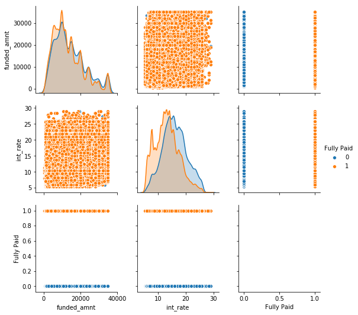

```python
#先用散列图来观察变量的关系
import seaborn as sns
# sns.pairplot(df_clean[['Fully Paid', 'funded_amnt','int_rate','OWN','RENT', 'annual_inc']], hue="Fully Paid");
# 观察连续的数值特征与结果之前的关系图
# 贷款信息类的数值特征
sns.pairplot(df_clean[['funded_amnt','int_rate', 'Fully Paid']], hue='Fully Paid');
```

```python
df_clean[' 60 months'].unique()
df_clean[df_clean['Fully Paid'] == 1].groupby(' 60 months')['Fully Paid'].count()
```

```
 60 months
0    167429
1     40143
Name: Fully Paid, dtype: int64
```

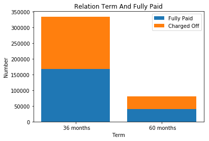

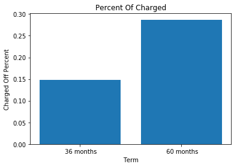

```python
# 贷款信息类的贷款期限的特征
# 这里我计算每个特征的比例
# 这里图示正常与坏账的数量
plt.figure(1)
df_paid = df_clean[df_clean['Fully Paid'] == 1].groupby('term')['Fully Paid'].count()
plt.bar(df_paid.index, df_paid, label='Fully Paid')
df_charged = df_clean[df_clean['Fully Paid'] == 0].groupby('term')['Fully Paid'].count()
plt.bar(df_charged.index, df_paid, bottom=df_paid, label='Charged Off')
plt.legend()
plt.xlabel('Term')
plt.ylabel('Number')
plt.title('Relation Term And Fully Paid')

# 这里图示是坏账率显示
plt.figure(2)
plt.bar(df_charged.index, df_charged / (df_charged + df_paid))
plt.xlabel('Term')
plt.ylabel('Charged Off Percent')
plt.title('Percent Of Charged')
```

#### 通过坏账和正常的比例图，可以看出。 60个月的贷款，坏账率较高。

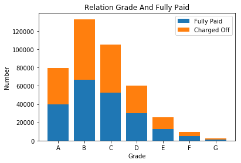

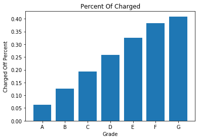

```python
#计算贷款等级特征
#当前正常和坏账的数量显示
df_paid = df_clean[df_clean['Fully Paid'] == 1].groupby('grade')['Fully Paid'].count()
plt.bar(df_paid.index, df_paid, label='Fully Paid')
df_charged = df_clean[df_clean['Fully Paid'] == 0].groupby('grade')['Fully Paid'].count()
plt.bar(df_paid.index, df_paid, bottom=df_paid, label='Charged Off')
plt.legend()
plt.xlabel('Grade')
plt.ylabel('Number')
plt.title('Relation Grade And Fully Paid')

# 这里图示是坏账率显示
plt.figure(2)
plt.bar(df_charged.index, df_charged / (df_charged + df_paid))
plt.xlabel('Grade')
plt.ylabel('Charged Off Percent')
plt.title('Percent Of Charged')
```

#### 很明显的是贷款的评级越高(A) 坏账率越低

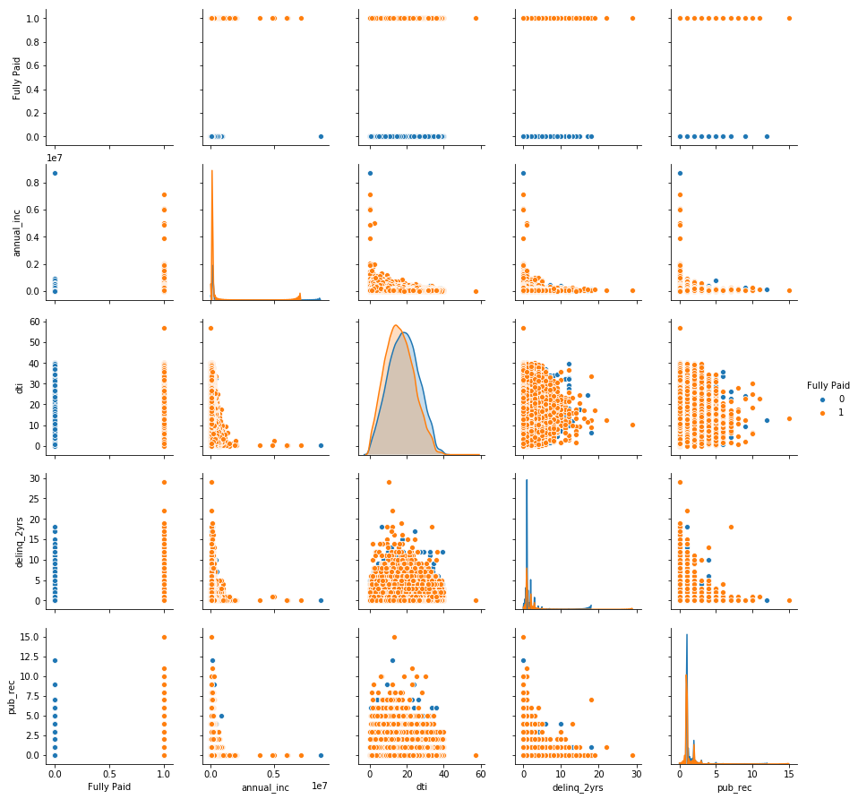

```python
# 用户信息类的数值特征
sns.pairplot(df_clean[['Fully Paid', 'annual_inc', 'dti', 'delinq_2yrs', 'pub_rec']], hue="Fully Paid");
```

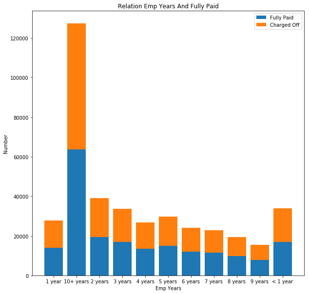

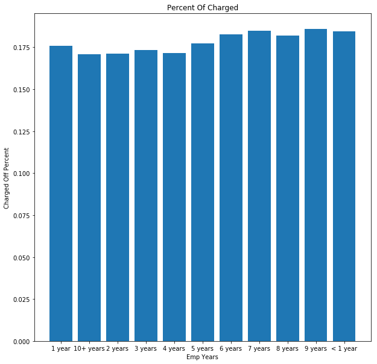

```python
# 用户信息类的用户工作年限的特征
# 这里我计算每个特征的比例
# 这里图示正常与坏账的数量
plt.figure(figsize=(10,10))
df_paid = df_clean[df_clean['Fully Paid'] == 1].groupby('emp_length')['Fully Paid'].count()
plt.bar(df_paid.index, df_paid, label='Fully Paid')
df_charged = df_clean[df_clean['Fully Paid'] == 0].groupby('emp_length')['Fully Paid'].count()
plt.bar(df_charged.index, df_paid, bottom=df_paid, label='Charged Off')
plt.legend()
plt.xlabel('Emp Years')
plt.ylabel('Number')
plt.title('Relation Emp Years And Fully Paid')

# 这里图示是坏账率显示
plt.figure(figsize=(10,10))
plt.bar(df_charged.index, df_charged / (df_charged + df_paid))
plt.xlabel('Emp Years')
plt.ylabel('Charged Off Percent')
plt.title('Percent Of Charged')
```

#### 说明工作年限和坏账率之间并没有直接关联。

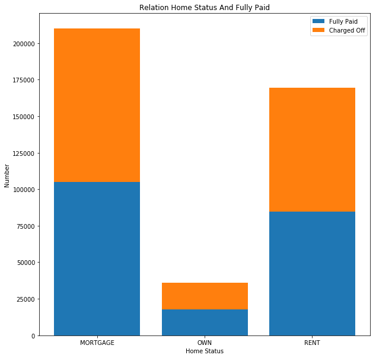

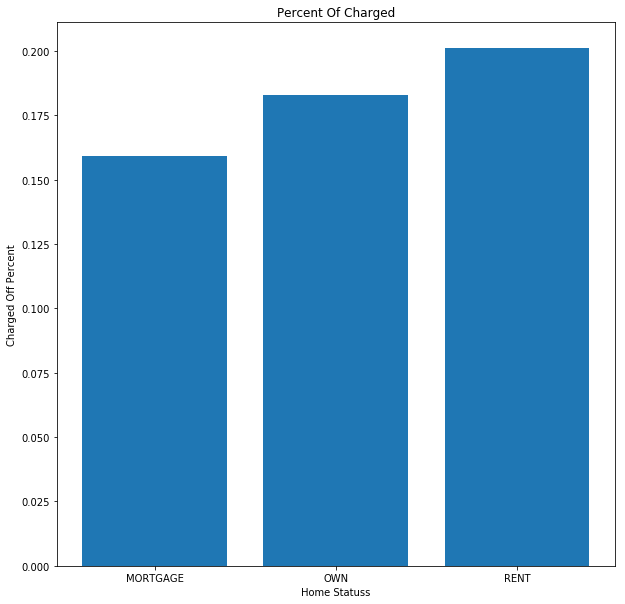

```python
# 用户信息类的用户住房的特征
plt.figure(figsize=(10,10))
df_paid = df_clean[df_clean['Fully Paid'] == 1].groupby('home_ownership')['Fully Paid'].count()
plt.bar(df_paid.index, df_paid, label='Fully Paid')
df_charged = df_clean[df_clean['Fully Paid'] == 0].groupby('home_ownership')['Fully Paid'].count()
plt.bar(df_charged.index, df_paid, bottom=df_paid, label='Charged Off')
plt.legend()
plt.xlabel('Home Status')
plt.ylabel('Number')
plt.title('Relation Home Status And Fully Paid')

# 这里图示是坏账率显示
plt.figure(figsize=(10,10))
plt.bar(df_charged.index, df_charged / (df_charged + df_paid))
plt.xlabel('Home Statuss')
plt.ylabel('Charged Off Percent')
plt.title('Percent Of Charged')
```

#### 这里可以看出，租房者的坏账率更高。

```python
#删除已经生成虚拟变量的变量
df_clean = df_clean.drop(['home_ownership', 'emp_length', 'term', 'grade', 'loan_status'],axis=1)
df_clean.head()
```

|  | annual_inc | dti | delinq_2yrs | pub_rec | funded_amnt | int_rate | 10+ years | 2 years | 3 years | 4 years | ... | OWN | RENT | 60 months | B | C | D | E | F | G | Fully Paid |
| --- | --- | --- | --- | --- | --- | --- | --- | --- | --- | --- | --- | --- | --- | --- | --- | --- | --- | --- | --- | --- | --- |
| 0 | 24000 | 27.65 | 0 | 0 | 5000 | 10.65 | 1 | 0 | 0 | 0 | ... | 0 | 1 | 0 | 1 | 0 | 0 | 0 | 0 | 0 | 1 |
| 1 | 30000 | 1 | 0 | 0 | 2500 | 15.27 | 0 | 0 | 0 | 0 | ... | 0 | 1 | 1 | 0 | 1 | 0 | 0 | 0 | 0 | 0 |
| 2 | 12252 | 8.72 | 0 | 0 | 2400 | 15.96 | 1 | 0 | 0 | 0 | ... | 0 | 1 | 0 | 0 | 1 | 0 | 0 | 0 | 0 | 1 |
| 3 | 49200 | 20 | 0 | 0 | 10000 | 13.49 | 1 | 0 | 0 | 0 | ... | 0 | 1 | 0 | 0 | 1 | 0 | 0 | 0 | 0 | 1 |
| 5 | 36000 | 11.2 | 0 | 0 | 5000 | 7.9 | 0 | 0 | 1 | 0 | ... | 0 | 1 | 0 | 0 | 0 | 0 | 0 | 0 | 0 | 1 |

5 rows × 26 columns

```python
#这里要使用逻辑回归的函数
#使用sklearn.cross_validation里的train_test_split模块分割数据集
from sklearn.model_selection import train_test_split
X_train,X_test,y_train,y_test = train_test_split(df_clean.drop(['Fully Paid'], axis=1),df_clean['Fully Paid'], test_size = 0.2,random_state = 33)
y_train.value_counts()
```

```
1    166154
0     36074
Name: Fully Paid, dtype: int64
```

```python
#查看测试集的数据
y_test.value_counts()
```

```
1    41418
0     9140
Name: Fully Paid, dtype: int64
```

```python
#引入逻辑回归
from sklearn.linear_model import LogisticRegression
from sklearn.metrics import confusion_matrix, precision_score, recall_score, accuracy_score

log_mod = LogisticRegression()
#拟合数据
log_mod.fit(X_train, y_train)

#预测数据
y_predict = log_mod.predict(X_test)
```

#### 说明

我们使用逻辑回归函数，预测出逻辑回归的模型。

## IV. 结果

### 模型的评价与验证

```python
#模型评估
print(recall_score(y_test, y_predict))
print(accuracy_score(y_test, y_predict))
print(precision_score(y_test, y_predict))
```

```
1.0
0.8192175323390957
0.8192175323390957
```

#### 感觉良好，有`81.9%`的精确率

```python
#继续生成详细的预测报告
from sklearn.metrics import classification_report
print(classification_report(y_test,y_predict,target_names=['Charged Off','Fully Paid']))
```

```
              precision    recall  f1-score   support

 Charged Off       0.00      0.00      0.00      9140
  Fully Paid       0.82      1.00      0.90     41418

   micro avg       0.82      0.82      0.82     50558
   macro avg       0.41      0.50      0.45     50558
weighted avg       0.67      0.82      0.74     50558
```

#### 说明

通过使用classification_report模块获得了当前模型的三个指标的结果（召回率，精确率，调和平均数） 可以发现，虽然有81.9%的精确度。但是其实只能单方面预测。是有巨大误差的。需要研究改进。

## V. 项目结论

我们通过逻辑回归来预测贷款的风险。通过选定的特征，训练出分类模型。然而，当前模型并不能很好的预测出结果。需要额外的探索改进。

### 对项目的思考

我们通过以下方式去预测坏账率

- 收集数据: 获取历史贷款记录数据和字段说明数据。
- 准备数据: 读取数据集，并且获取数据集的基本信息。
- 分析数据: 提取可能的特征。清理异常和缺失值。处理虚拟变量。
- 训练算法: 通过分析，使用逻辑回归的算法。找到最佳系数。
- 测试算法: 量化回归结果，观察精确率和召回率。 通过以上过程，我们可以训练出预想的逻辑回归模型。然而，数据集过于庞大而且特征繁多。给预测带来的很多不确定性。 我们需要分析出可能的特征，才有可能正确预测特性。

### 需要作出的改进

当前的分类模型的预测是有巨大误差的，需要改进。以下是我所考虑能改进的方向

- 数据归一化
- 找到新的特征

```python
#找到需要归一化的字段
df_cal = df_clean[['annual_inc','dti','delinq_2yrs', 'pub_rec','funded_amnt','int_rate']]
# 归一化处理
df_cal = (df_cal - df_cal.mean())/ df_cal.std()
df_cal.head()
```

|  | annual_inc | dti | delinq_2yrs | pub_rec | funded_amnt | int_rate |
| --- | --- | --- | --- | --- | --- | --- |
| 0 | -0.825326 | 1.42585 | -0.337398 | -0.328807 | -1.05099 | -0.707532 |
| 1 | -0.723313 | -1.99596 | -0.337398 | -0.328807 | -1.35925 | 0.341868 |
| 2 | -1.02507 | -1.00473 | -0.337398 | -0.328807 | -1.37158 | 0.498597 |
| 3 | -0.396871 | 0.443604 | -0.337398 | -0.328807 | -0.434471 | -0.0624463 |
| 5 | -0.6213 | -0.686301 | -0.337398 | -0.328807 | -1.05099 | -1.33218 |

```python
# 使用归一化后的字段来预测
X_train,X_test,y_train,y_test = train_test_split(df_cal,df_clean['Fully Paid'], test_size = 0.2,random_state = 33)

#拟合数据
log_mod.fit(X_train, y_train)

#预测数据
y_predict = log_mod.predict(X_test)
```

```python
#模型评估
print(recall_score(y_test, y_predict))
print(accuracy_score(y_test, y_predict))
print(precision_score(y_test, y_predict))
```

```
0.9932396542566034
0.8191779738122552
0.82276
```

#### 说明

精确度感觉有所变化，我们调用详细函数查看

```python
print(classification_report(y_test,y_predict,target_names=['Charged Off','Fully Paid']))
```

```
              precision    recall  f1-score   support

 Charged Off       0.50      0.03      0.06      9140
  Fully Paid       0.82      0.99      0.90     41418

   micro avg       0.82      0.82      0.82     50558
   macro avg       0.66      0.51      0.48     50558
weighted avg       0.76      0.82      0.75     50558
```

```python
# 混淆矩阵
confusion_matrix(y_test,y_predict)
```

```
array([[  278,  8862],
       [  280, 41138]], dtype=int64)
```

#### 说明

在数据归一化之后，确实对结果的预测起到了正向结果。 这里我们发现，我们预测坏账率上，确实有所提升。说明归一化可以优化算法结果的。

```python
#我们尝试使用新的特征来做预测
#total_acc 借款人信用档案中，当前信用额度总数 float
#通过Index获取到筛选的数据
df_acc = df.loc[df_clean.index].total_acc
df_acc.columns=['total_acc']
df_acc.head()
```

```
0     9
1     4
2    10
3    37
5    12
Name: total_acc, dtype: object
```

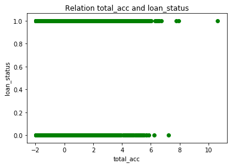

```python
#用图表分析该特征和结果之间的关系
#缩放
df_acc = (df_acc - df_acc.mean())/df_acc.std()
plt.scatter(x=df_acc, y=df_clean['Fully Paid'], c='g');
plt.xlabel('total_acc')
plt.ylabel('loan_status')
plt.title('Relation total_acc and loan_status')
```

#### 说明

与结果之间并没有明显的相关性。

```python
#尝试使用installment
df_ins = df.loc[df_clean.index].installment
df_ins.columns=['installment']
df_ins.head()
```

```
0    162.87
1     59.83
2     84.33
3    339.31
5    156.46
Name: installment, dtype: object
```

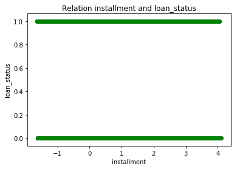

```python
#用图表分析该特征和结果之间的关系
#缩放
df_ins = (df_ins - df_ins.mean())/df_ins.std()
plt.scatter(x=df_ins, y=df_clean['Fully Paid'], c='g');
plt.xlabel('installment')
plt.ylabel('loan_status')
plt.title('Relation installment and loan_status')
```

```python
#加入备选特征去预测模型
df_cal = df_cal.join(df_acc).join(df_ins)
# 使用归一化后的字段来预测
X_train,X_test,y_train,y_test = train_test_split(df_cal,df_clean['Fully Paid'], test_size = 0.2,random_state = 33)

#拟合数据
log_mod.fit(X_train, y_train)

#预测数据
y_predict = log_mod.predict(X_test)
```

```python
#模型评估
print(recall_score(y_test, y_predict))
print(accuracy_score(y_test, y_predict))
print(precision_score(y_test, y_predict))
```

```
0.9922497464870346
0.8188021678072709
0.8229769509582073
```

```python
#精度有细微变化
# 混淆矩阵
confusion_matrix(y_test,y_predict)
```

```
array([[  300,  8840],
       [  321, 41097]], dtype=int64)
```

#### 说明

在添加可能性特征进入预测模型之后，并没有对结果产生足够的影响。

[figure not shown]

```python
# 引入roc，来确定当前预测的覆盖率
from sklearn.metrics import roc_curve, auc

preds = log_mod.predict_proba(X_test)[:,1]
fpr, tpr, _ = roc_curve(y_test, preds)
#绘制Roc曲线
plt.plot(fpr, tpr, color='darkorange', lw=2, label='ROC curve of class 1 (area = 1)')
plt.xlim([0.0, 1.0])
plt.ylim([0.0, 1.05])
plt.xlabel('Charge Off Rate')
plt.ylabel('Fully Paid Rate')
plt.legend(loc="lower right")
plt.title('Loan status ROC')
```